# Code

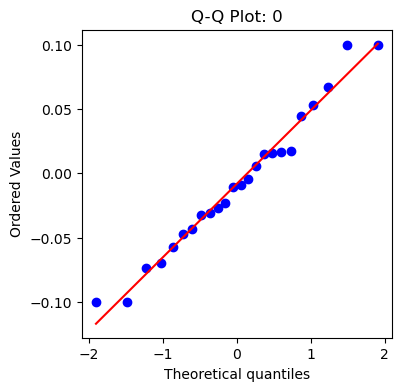

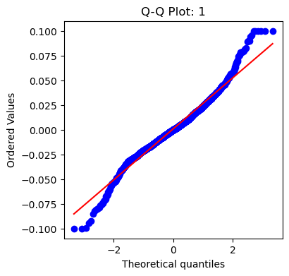

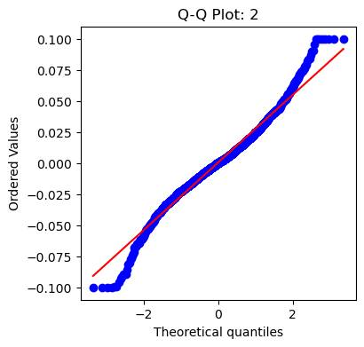

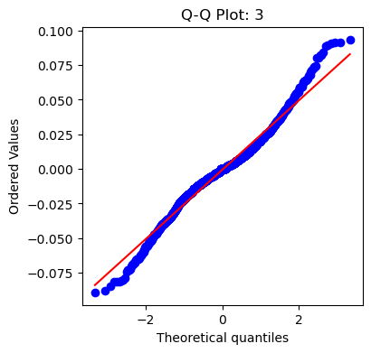

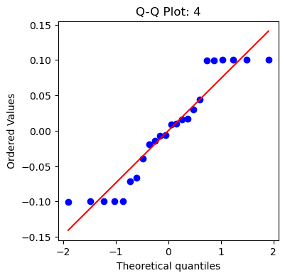

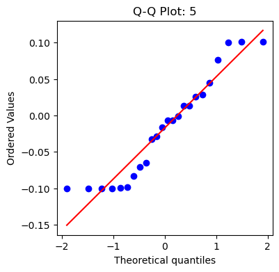

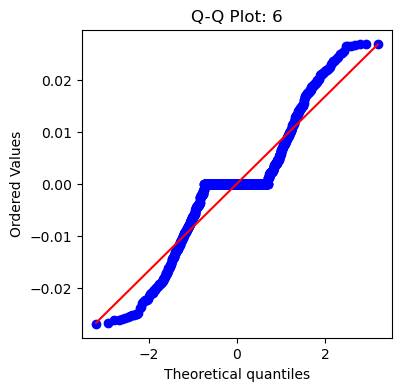

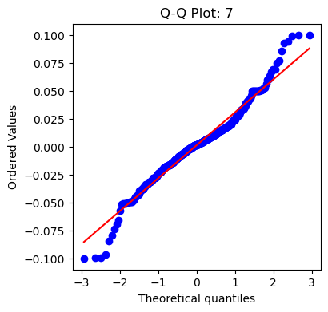

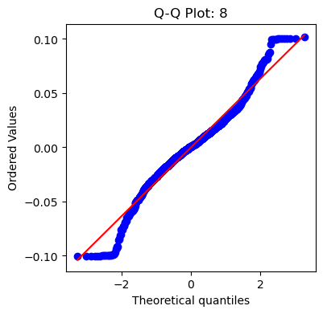

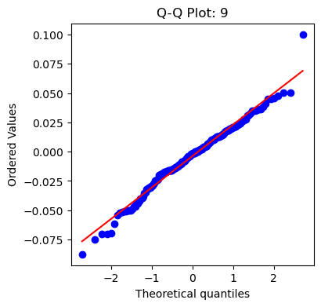

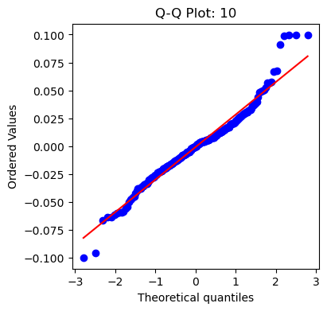

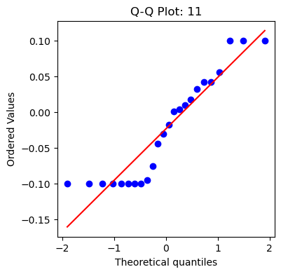

[38 more figures not shown]

```python
for stock in returns.index[:50]:
    plt.figure(figsize=(4,4))
    stats.probplot(returns.loc[stock].dropna(), dist="norm", plot=plt)
    plt.title(f"Q-Q Plot: {stock}")
    plt.show()
```

```python
returns
```

| stock_id | 0 | 1 | 2 | 3 | 4 | 5 | 6 | 7 | 8 | 9 | ... | 1820 | 1821 | 1822 | 1823 | 1824 | 1825 | 1826 | 1827 | 1828 | 1829 |
| --- | --- | --- | --- | --- | --- | --- | --- | --- | --- | --- | --- | --- | --- | --- | --- | --- | --- | --- | --- | --- | --- |
| 0 | NaN | NaN | NaN | NaN | NaN | NaN | NaN | NaN | NaN | NaN | ... | 0.053357 | -0.032410 | -0.073869 | -0.070180 | 0.005667 | 0.014600 | -0.099975 | 0.100140 | 0.099949 | 0.044738 |
| 1 | NaN | -0.010360 | 0.028206 | -0.008803 | 0.079349 | 0.033537 | 0.003136 | 0.013027 | 0.001029 | -0.026246 | ... | NaN | NaN | NaN | NaN | NaN | NaN | NaN | NaN | NaN | NaN |
| 2 | NaN | -0.001402 | 0.038422 | -0.009663 | -0.058645 | 0.018851 | 0.061989 | 0.060605 | 0.022136 | -0.021657 | ... | NaN | NaN | NaN | NaN | NaN | NaN | NaN | NaN | NaN | NaN |
| 3 | NaN | 0.038121 | -0.002623 | 0.013149 | -0.002920 | -0.001627 | 0.026728 | -0.020635 | -0.008104 | 0.013072 | ... | NaN | NaN | NaN | NaN | NaN | NaN | NaN | NaN | NaN | NaN |
| 4 | NaN | NaN | NaN | NaN | NaN | NaN | NaN | NaN | NaN | NaN | ... | 0.009360 | 0.098918 | -0.099859 | -0.100000 | -0.099826 | -0.100289 | -0.099678 | 0.100000 | 0.099567 | -0.005906 |
| ... | ... | ... | ... | ... | ... | ... | ... | ... | ... | ... | ... | ... | ... | ... | ... | ... | ... | ... | ... | ... | ... |
| 2071 | NaN | NaN | NaN | NaN | NaN | NaN | NaN | NaN | NaN | NaN | ... | NaN | NaN | -0.099896 | -0.099807 | NaN | -0.100044 | -0.099951 | NaN | NaN | NaN |
| 2072 | NaN | NaN | NaN | NaN | NaN | NaN | NaN | NaN | NaN | NaN | ... | -0.050346 | -0.059598 | -0.099853 | -0.099877 | -0.025466 | -0.099860 | -0.100052 | NaN | NaN | NaN |
| 2073 | NaN | NaN | NaN | NaN | NaN | NaN | NaN | NaN | NaN | NaN | ... | 0.091256 | -0.053919 | -0.036148 | -0.027649 | 0.058277 | -0.099761 | -0.064716 | 0.100158 | 0.099943 | 0.100000 |
| 2074 | NaN | NaN | NaN | NaN | NaN | NaN | NaN | NaN | NaN | NaN | ... | 0.082192 | -0.080696 | -0.037005 | -0.097408 | 0.050495 | -0.098021 | 0.000000 | 0.100313 | 0.099715 | 0.100173 |
| 2075 | NaN | NaN | NaN | NaN | NaN | NaN | NaN | NaN | NaN | NaN | ... | 0.072133 | -0.083381 | -0.098494 | -0.100209 | -0.019335 | -0.100158 | -0.099912 | 0.100292 | 0.100000 | 0.099759 |

2076 rows × 1830 columns

Question 5

```python
market_index = returns.mean(axis=0)
```

```python
market_index
```

```
0            NaN
1       0.022361
2       0.005560
3       0.019971
4      -0.027867
          ...
1825   -0.095920
1826   -0.071019
1827    0.098047
1828    0.098078
1829    0.093931
Length: 1830, dtype: float64
```

```python
market_index
```

```
0            NaN
1       0.022361
2       0.005560
3       0.019971
4      -0.027867
          ...
1825   -0.095920
1826   -0.071019
1827    0.098047
1828    0.098078
1829    0.093931
Length: 1830, dtype: float64
```

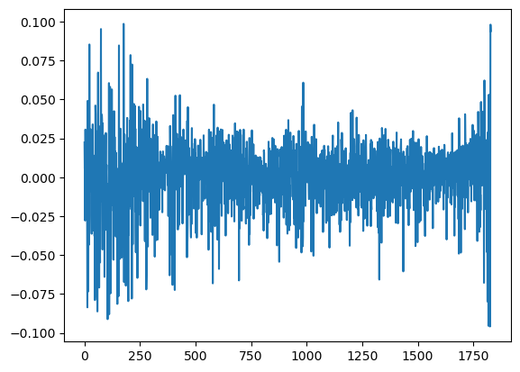

```python
market_index.plot()
```

Question 6

```python
import pandas as pd
import numpy as np
import statsmodels.api as sm

# returns_clean: rows = stocks, columns = dates
# market_index: Series indexed by same dates (columns of returns_clean)

betas = []
alphas = []
stock_ids = []
r2_list = []
std = []
residual_std = []
```

```python
for stock in returns.index:

    # stock's cleaned return series
    r_i = returns.loc[stock]

    # align returns with market index
    df_xy = pd.concat([r_i, market_index], axis=1)
    df_xy.columns = ["ri", "rm"]

    # remove NaNs
    df_xy = df_xy.dropna()

    if len(df_xy) < 20:   # require enough data points
        betas.append(np.nan)
        alphas.append(np.nan)
        r2_list.append(np.nan)
        stock_ids.append(stock)
        continue

    # regression: ri = alpha + beta * rm
    X = sm.add_constant(df_xy["rm"])
    y = df_xy["ri"]

    model = sm.OLS(y, X).fit()

    resid = model.resid  # residual series
    std_r = df_xy["ri"].std(ddof=1)           # sample standard deviation
    std_resid = resid.std(ddof=1)

    alphas.append(model.params["const"])
    betas.append(model.params["rm"])
    r2_list.append(model.rsquared)
    stock_ids.append(stock)
    std.append(std_r)
    residual_std.append(std_resid)
```

```python
len(stock_ids)
```

```
2076
```

```python
r_i
```

```
0            NaN
1            NaN
2            NaN
3            NaN
4            NaN
          ...
1825   -0.100158
1826   -0.099912
1827    0.100292
1828    0.100000
1829    0.099759
Name: 2075, Length: 1830, dtype: float64
```

```python
len(betas)
```

```
2076
```

```python
len(alphas)
```

```
2076
```

```python
betas=pd.DataFrame(betas)
```

```python
betas.dropna().describe()
```

|  | 0 |
| --- | --- |
| count | 2051.000000 |
| mean | 1.016821 |
| std | 0.179888 |
| min | 0.100534 |
| 25% | 0.931192 |
| 50% | 1.024823 |
| 75% | 1.115001 |
| max | 1.858771 |

```python
betas.dropna().mean() #1.01~1
```

```
0    1.016821
dtype: float64
```

Question 7

The average beta across all stocks should be approximately 1 Why? Because: The market return is the average of all stocks. Beta measures how each stock moves relative to the market. If you average all stocks' betas, you are effectively measuring how the market moves relative to itself. The market’s beta relative to the market = 1.

```python
len(std)
```

```
2051
```

```python
std_df= pd.DataFrame(std)
```

```python
std_df.describe()
```

|  | 0 |
| --- | --- |
| count | 2051.000000 |
| mean | 0.032799 |
| std | 0.009863 |
| min | 0.009022 |
| 25% | 0.027840 |
| 50% | 0.031270 |
| 75% | 0.034751 |
| max | 0.085200 |

```python
residual_std_df= pd.DataFrame(residual_std)
```

```python
residual_std_df.describe()
```

|  | 0 |
| --- | --- |
| count | 2051.000000 |
| mean | 0.023785 |
| std | 0.005678 |
| min | 0.007264 |
| 25% | 0.020476 |
| 50% | 0.023116 |
| 75% | 0.026214 |
| max | 0.066297 |

```python
std_df[0]
```

```
0       0.055249
1       0.026136
2       0.027516
3       0.025325
4       0.073766
          ...
2046    0.067862
2047    0.057123
2048    0.064892
2049    0.068549
2050    0.078293
Name: 0, Length: 2051, dtype: float64
```

Question 8

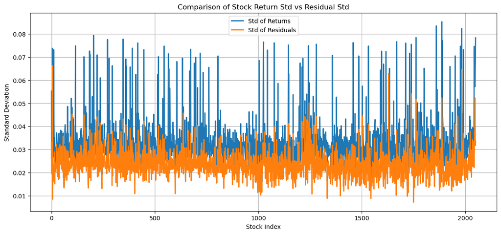

```python
import matplotlib.pyplot as plt

# Make sure indices align (stocks in same order)
std_r = std_df[0]
std_e = residual_std_df[0]

plt.figure(figsize=(14,6))

plt.plot(std_r.values, label="Std of Returns", linewidth=2)
plt.plot(std_e.values, label="Std of Residuals", linewidth=2)

plt.title("Comparison of Stock Return Std vs Residual Std")
plt.xlabel("Stock Index")
plt.ylabel("Standard Deviation")
plt.legend()
plt.grid(True)
plt.show()
```

The standard deviation of returns is higher than the standard deviation of residuals because returns include both market and stock-specific volatility, while residuals include only stock-specific volatility. Once the market component is removed through regression, the remaining variation necessarily declines.

```python
market_index.loc[returns.columns]
```

```
0            NaN
1       0.022361
2       0.005560
3       0.019971
4      -0.027867
          ...
1825   -0.095920
1826   -0.071019
1827    0.098047
1828    0.098078
1829    0.093931
Length: 1830, dtype: float64
```

Question 9- Code for calculating rolling Betas

```python
WINDOW = 250   # 250-day rolling window

# Make sure data aligns
market = market_index.loc[returns.columns]

# Prepare a DataFrame to store rolling betas
rolling_betas = pd.DataFrame(index=returns.index, columns=returns.columns)

for stock in returns.index:

    r_i = returns.loc[stock]
    # print(stock)

    # Loop over all possible end dates
    for t in range(WINDOW, len(returns.columns)):

        # Select 250-day window
        window_r_i = r_i.iloc[t-WINDOW:t]
        window_rm  = market.iloc[t-WINDOW:t]

        # Drop NaNs
        df_xy = pd.concat([window_r_i, window_rm], axis=1).dropna()
        df_xy.columns = ["ri","rm"]

        # Require sufficient data in the window
        if len(df_xy) < 50:
            continue

        X = sm.add_constant(df_xy["rm"])
        y = df_xy["ri"]

        model = sm.OLS(y, X).fit()
        rolling_betas.iloc[rolling_betas.index.get_loc(stock), t] = model.params["rm"]
```

```python
rolling_betas= pd.DataFrame(rolling_betas)
```

```python
rolling_betas.to_csv('rolling_betas.csv')
```

```python
rolling_betas= pd.read_csv('rolling_betas.csv')
```

```python
rolling_betas= pd.DataFrame(rolling_betas)
```

```python
rolling_betas.columns
```

```
Index(['Unnamed: 0', 'stock_id', '0', '1', '2', '3', '4', '5', '6', '7',
       ...
       '1820', '1821', '1822', '1823', '1824', '1825', '1826', '1827', '1828',
       '1829'],
      dtype='object', length=1832)
```

```python
rolling_betas= rolling_betas.drop('Unnamed: 0',axis=1)
```

```python
rolling_betas = rolling_betas.set_index('stock_id')
```

```python
rolling_betas
```

| stock_id | 0 | 1 | 2 | 3 | 4 | 5 | 6 | 7 | 8 | 9 | ... | 1820 | 1821 | 1822 | 1823 | 1824 | 1825 | 1826 | 1827 | 1828 | 1829 |
| --- | --- | --- | --- | --- | --- | --- | --- | --- | --- | --- | --- | --- | --- | --- | --- | --- | --- | --- | --- | --- | --- |
| 0 | NaN | NaN | NaN | NaN | NaN | NaN | NaN | NaN | NaN | NaN | ... | NaN | NaN | NaN | NaN | NaN | NaN | NaN | NaN | NaN | NaN |
| 1 | NaN | NaN | NaN | NaN | NaN | NaN | NaN | NaN | NaN | NaN | ... | 0.726321 | 0.727175 | 0.727546 | 0.727014 | 0.727460 | 0.727677 | 0.727696 | 0.727863 | 0.727842 | 0.727883 |
| 2 | NaN | NaN | NaN | NaN | NaN | NaN | NaN | NaN | NaN | NaN | ... | 0.794293 | 0.795794 | 0.795848 | 0.796483 | 0.797586 | 0.797504 | 0.797968 | 0.797911 | 0.798136 | 0.798354 |
| 3 | NaN | NaN | NaN | NaN | NaN | NaN | NaN | NaN | NaN | NaN | ... | 0.787010 | 0.787010 | 0.787010 | 0.787010 | 0.787010 | 0.787010 | 0.787010 | 0.787010 | 0.787010 | 0.787010 |
| 4 | NaN | NaN | NaN | NaN | NaN | NaN | NaN | NaN | NaN | NaN | ... | NaN | NaN | NaN | NaN | NaN | NaN | NaN | NaN | NaN | NaN |
| ... | ... | ... | ... | ... | ... | ... | ... | ... | ... | ... | ... | ... | ... | ... | ... | ... | ... | ... | ... | ... | ... |
| 2071 | NaN | NaN | NaN | NaN | NaN | NaN | NaN | NaN | NaN | NaN | ... | NaN | NaN | NaN | NaN | NaN | NaN | NaN | NaN | NaN | NaN |
| 2072 | NaN | NaN | NaN | NaN | NaN | NaN | NaN | NaN | NaN | NaN | ... | NaN | NaN | NaN | NaN | NaN | NaN | NaN | NaN | NaN | NaN |
| 2073 | NaN | NaN | NaN | NaN | NaN | NaN | NaN | NaN | NaN | NaN | ... | NaN | NaN | NaN | NaN | NaN | NaN | NaN | NaN | NaN | NaN |
| 2074 | NaN | NaN | NaN | NaN | NaN | NaN | NaN | NaN | NaN | NaN | ... | NaN | NaN | NaN | NaN | NaN | NaN | NaN | NaN | NaN | NaN |
| 2075 | NaN | NaN | NaN | NaN | NaN | NaN | NaN | NaN | NaN | NaN | ... | NaN | NaN | NaN | NaN | NaN | NaN | NaN | NaN | NaN | NaN |

2076 rows × 1830 columns

```python
import pandas as pd
import matplotlib.pyplot as plt

def plot_row_histograms(df):
    """
    df: DataFrame with stock_id as index and dates as columns.
    Plots a histogram for each stock (each row).
    """
    top10= df.head(50)
    for stock_id, row in top10.iterrows():
        plt.figure(figsize=(8, 4))
        plt.hist(row.dropna(), bins=5)
        plt.title(f"Histogram for {stock_id}")
        plt.xlabel("Value")
        plt.ylabel("Frequency")
        plt.tight_layout()
        plt.show()
```

[figure not shown]

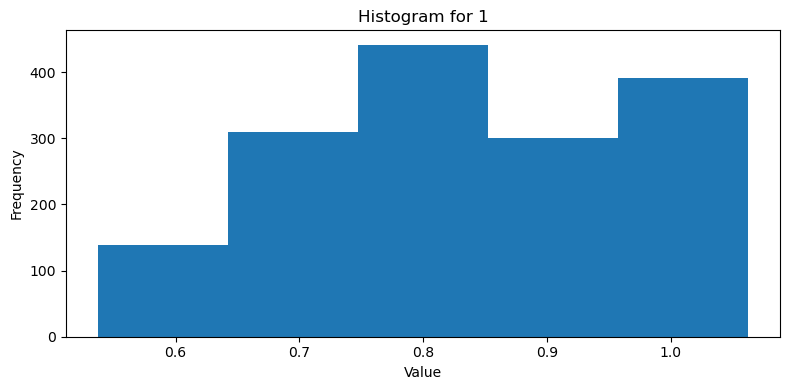

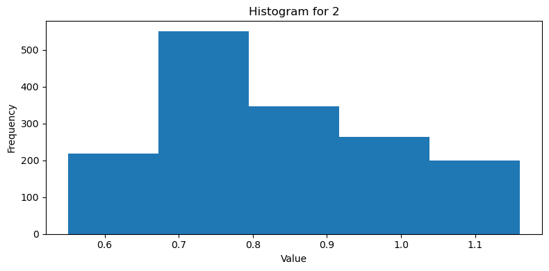

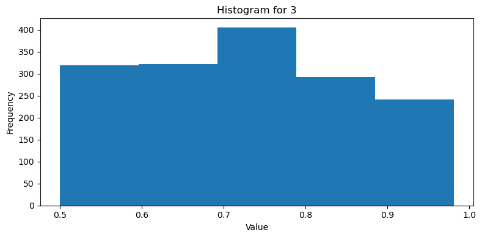

[figure not shown]

[figure not shown]

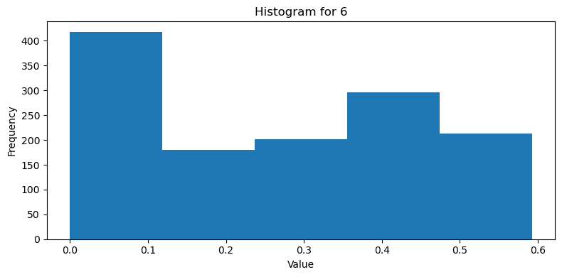

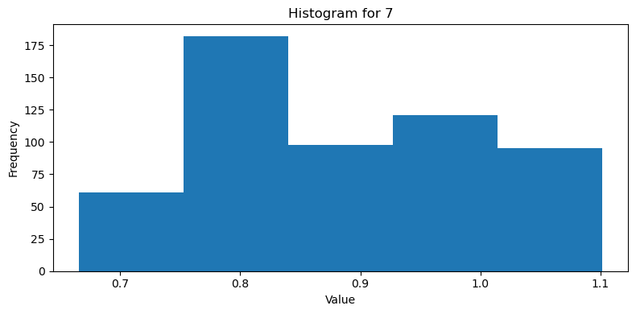

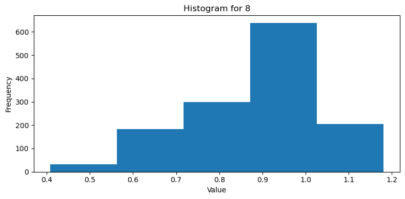

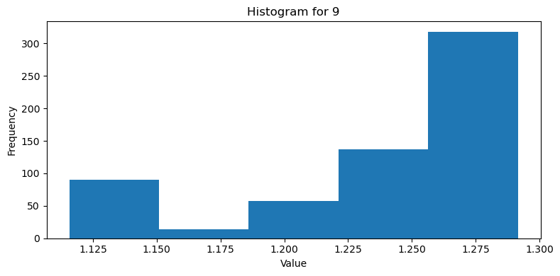

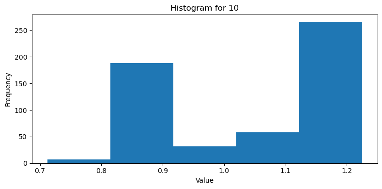

[figure not shown]

[38 more figures not shown]

```python
plot_row_histograms(rolling_betas)
```

Question 10

Rolling stock-level betas provide a useful backward-looking measure of systematic risk, but they are not very reliable predictors of future beta. Individual stock betas are inherently noisy because idiosyncratic volatility dominates market-related variation, leading to high estimation error even with long windows such as 250 days. In practice, a company’s risk exposure changes over time due to shifts in leverage, business models, industry conditions, and market regimes, making historical betas slow to adjust. As a result, raw rolling betas tend to be unstable and exhibit weak out-of-sample predictive power

Question 11

A more robust estimate of future betas can be obtained by reducing the noise and instability inherent in raw rolling-window regressions. One improvement is to apply shrinkage (e.g., Blume or Vasicek), which pulls noisy estimates toward a long-run or industry-level beta. Another approach is to estimate portfolio or sector betas, which diversify idiosyncratic noise. Using time-varying models can also help: for example, computing beta using EWMA (Exponentially Weighted Moving Averages) gives more weight to recent data and adapts more smoothly to changing market regimes, improving out-of-sample stability.